# Chapter 5, Value of Plays Using Run Expectancy

OR 476: Sports Analytics · Lessons 11–13

```r
library(tidyverse)
```

## 5.1 The Run Expectancy Matrix

The general process for determining the value of a play/action in any sport involves:

1. “Pause” the game. Measure the state of the game and the **expected value of game state pre-action.**
2. “Unpause” the game and collect data on all **actions that take place** (e.g., a pitch, a hit, stolen base)
3. “Pause” the game again. Measure the state of the game and the **expected value of the game state post-action**.
4. **Calculate the change in expected value** from pre-action to post-action. The change in value is attributed to players involved in the action.

In baseball, we use 24 possible base-out states that describe that current state of the game when we “pause” the game.

We can use 4 numbers to describe the baseout state. The first three numbers capture whether each of the 3 bases are occupied or not. The fourth number is the number of outs. For example:

- 0000 implies nobody on, 0 outs
- 1012 implies man on 1st, man on 3rd, 2 outs

**Run expectancy** is the average number of runs a team goes on to score from a given base-out state to the end of the half-inning. The run expectancy is a **value function** over the 24 base-out states. The run expectancy tells us, on average, which states are preferable over others.

Once we have $RE(S)$, the value of any play is one line: $\text{run\_value} = RE(\text{BO}_{post}) - RE(\text{BO}_{pre}) + \text{runs that scored}$

## 5.2 Runs Scored in the Remainder of the Inning

We load **2016** play-by-play data from Retrosheet. Note that this method differs from the how the book loads this data - either works.

```r
zip_path <- "data/2016plays.zip"

if (!file.exists(zip_path)) {
  download.file("https://www.retrosheet.org/downloads/plays/2016plays.zip",
                zip_path, mode = "wb")
}

retro2016 <- read_csv(zip_path)
head(retro2016, 3)
```

| gid | event | inning | top_bot | vis_home | site | batteam | pitteam | score_v | score_h | batter | pitcher | lp | bat_f | bathand | pithand | balls | strikes | count | pitches | nump | pa | ab | single | double | triple | hr | sh | sf | hbp | … |
| --- | --- | --- | --- | --- | --- | --- | --- | --- | --- | --- | --- | --- | --- | --- | --- | --- | --- | --- | --- | --- | --- | --- | --- | --- | --- | --- | --- | --- | --- | --- |
| KCA201604030 | 8/L8RD+ | 1 | 0 | 0 | KAN06 | NYN | KCA | 0 | 0 | granc001 | volqe001 | 1 | 9 | L | R | 2 | 2 | 22 | CCBBFX | 6 | 1 | 1 | 0 | 0 | 0 | 0 | 0 | 0 | 0 | … |
| KCA201604030 | 53/G5+ | 1 | 0 | 0 | KAN06 | NYN | KCA | 0 | 0 | wrigd002 | volqe001 | 2 | 5 | R | R | 2 | 2 | 22 | FSBBX | 5 | 1 | 1 | 0 | 0 | 0 | 0 | 0 | 0 | 0 | … |
| KCA201604030 | 63/G6MS- | 1 | 0 | 0 | KAN06 | NYN | KCA | 0 | 0 | cespy001 | volqe001 | 3 | 7 | R | R | 1 | 1 | 11 | BCX | 3 | 1 | 1 | 0 | 0 | 0 | 0 | 0 | 0 | 0 | … |

```r
glimpse(retro2016 |> head(3))
```

```
Rows: 3
Columns: 177
$ gid       <chr> "KCA201604030", "KCA201604030", "KCA201604030"
$ event     <chr> "8/L8RD+", "53/G5+", "63/G6MS-"
$ inning    <dbl> 1, 1, 1
$ top_bot   <dbl> 0, 0, 0
$ vis_home  <dbl> 0, 0, 0
$ site      <chr> "KAN06", "KAN06", "KAN06"
$ batteam   <chr> "NYN", "NYN", "NYN"
$ pitteam   <chr> "KCA", "KCA", "KCA"
$ score_v   <dbl> 0, 0, 0
$ score_h   <dbl> 0, 0, 0
$ batter    <chr> "granc001", "wrigd002", "cespy001"
$ pitcher   <chr> "volqe001", "volqe001", "volqe001"
$ lp        <dbl> 1, 2, 3
```

[output cut: 164 more lines]

We select the columns we need and then compute several new columns

```r
# Keep only regular-season plays and the columns we need, then add:
# runs in the game before the play, a unique id for each half-inning,
# and the runs scored on the play.
pbp <- retro2016
pbp <- pbp |>
  select(gid, inning, top_bot, batter, pitcher, score_v, score_h, pa,
         single, double, triple, hr, hbp, walk, k,
         sb2, cs2, bip, roe, fc, sf, sh,
         outs_pre, outs_post,
         br1_pre, br2_pre, br3_pre,
         br1_post, br2_post, br3_post,
         runs, pn, gametype) |>
  mutate(runs_pre = score_v + score_h,
         half_inning_id = paste(gid, inning, top_bot)) |>
  filter(gametype == "regular")
pbp
```

| gid | inning | top_bot | batter | pitcher | score_v | score_h | pa | single | double | triple | hr | hbp | walk | k | sb2 | cs2 | bip | roe | fc | sf | sh | outs_pre | outs_post | br1_pre | br2_pre | br3_pre | br1_post | br2_post | br3_post | … |
| --- | --- | --- | --- | --- | --- | --- | --- | --- | --- | --- | --- | --- | --- | --- | --- | --- | --- | --- | --- | --- | --- | --- | --- | --- | --- | --- | --- | --- | --- | --- |
| KCA201604030 | 1 | 0 | granc001 | volqe001 | 0 | 0 | 1 | 0 | 0 | 0 | 0 | 0 | 0 | 0 | 0 | 0 | 1 | 0 | 0 | 0 | 0 | 0 | 1 | NA | NA | NA | NA | NA | NA | … |
| KCA201604030 | 1 | 0 | wrigd002 | volqe001 | 0 | 0 | 1 | 0 | 0 | 0 | 0 | 0 | 0 | 0 | 0 | 0 | 1 | 0 | 0 | 0 | 0 | 1 | 2 | NA | NA | NA | NA | NA | NA | … |
| KCA201604030 | 1 | 0 | cespy001 | volqe001 | 0 | 0 | 1 | 0 | 0 | 0 | 0 | 0 | 0 | 0 | 0 | 0 | 1 | 0 | 0 | 0 | 0 | 2 | 3 | NA | NA | NA | NA | NA | NA | … |
| KCA201604030 | 1 | 1 | escoa003 | harvm001 | 0 | 0 | 1 | 0 | 0 | 0 | 0 | 0 | 0 | 0 | 0 | 0 | 1 | 0 | 0 | 0 | 0 | 0 | 1 | NA | NA | NA | NA | NA | NA | … |
| KCA201604030 | 1 | 1 | mousm001 | harvm001 | 0 | 0 | 1 | 0 | 0 | 0 | 0 | 0 | 0 | 0 | 0 | 0 | 1 | 1 | 0 | 0 | 0 | 1 | 1 | NA | NA | NA | mousm001 | NA | NA | … |
| KCA201604030 | 1 | 1 | cainl001 | harvm001 | 0 | 0 | 0 | 0 | 0 | 0 | 0 | 0 | 0 | 0 | 0 | 0 | 0 | 0 | 0 | 0 | 0 | 1 | 1 | mousm001 | NA | NA | NA | mousm001 | NA | … |
| KCA201604030 | 1 | 1 | cainl001 | harvm001 | 0 | 0 | 1 | 0 | 0 | 0 | 0 | 0 | 1 | 0 | 0 | 0 | 0 | 0 | 0 | 0 | 0 | 1 | 1 | NA | mousm001 | NA | cainl001 | mousm001 | NA | … |
| KCA201604030 | 1 | 1 | hosme001 | harvm001 | 0 | 0 | 1 | 1 | 0 | 0 | 0 | 0 | 0 | 0 | 0 | 0 | 1 | 0 | 0 | 0 | 0 | 1 | 1 | cainl001 | mousm001 | NA | hosme001 | NA | cainl001 | … |
| KCA201604030 | 1 | 1 | morak001 | harvm001 | 0 | 1 | 1 | 0 | 0 | 0 | 0 | 0 | 0 | 0 | 0 | 0 | 1 | 0 | 0 | 0 | 0 | 1 | 3 | hosme001 | NA | cainl001 | NA | NA | NA | … |
| KCA201604030 | 2 | 0 | dudal001 | volqe001 | 0 | 1 | 1 | 0 | 0 | 0 | 0 | 0 | 0 | 1 | 0 | 0 | 0 | 0 | 0 | 0 | 0 | 0 | 1 | NA | NA | NA | NA | NA | NA | … |

[output cut: 9990 more lines]

For each half-inning we need two numbers: the most outs recorded (to know if it is a *complete* inning), and the game score at the *end* of the half-inning.

We use the `half_innings` table to both filter our play-by-play data to complete half innings, and to merge the half-inning’s final score back onto every play — a number that is not available in the play-by-play data on its own. Later we subtract the score before each play from this final score to get the runs scored in the remainder of the inning.

```r
# Summarize down to one row per half-inning: the most outs recorded (to tell
# complete innings from partial ones) and the game score at the end of the
# half-inning (the running game score is monotonic, so its max is the final).

half_innings <- pbp |>
  group_by(half_inning_id) |>
  summarize(max_outs = max(outs_post),
            runs_final = max(runs_pre + runs))

half_innings
```

| half_inning_id | max_outs | runs_final |
| --- | --- | --- |
| ANA201604040 1 0 | 3 | 1 |
| ANA201604040 1 1 | 3 | 1 |
| ANA201604040 2 0 | 3 | 1 |
| ANA201604040 2 1 | 3 | 1 |
| ANA201604040 3 0 | 3 | 1 |
| ANA201604040 3 1 | 3 | 1 |
| ANA201604040 4 0 | 3 | 3 |
| ANA201604040 4 1 | 3 | 3 |
| ANA201604040 5 0 | 3 | 3 |
| ANA201604040 5 1 | 3 | 3 |

[output cut: 9990 more lines]

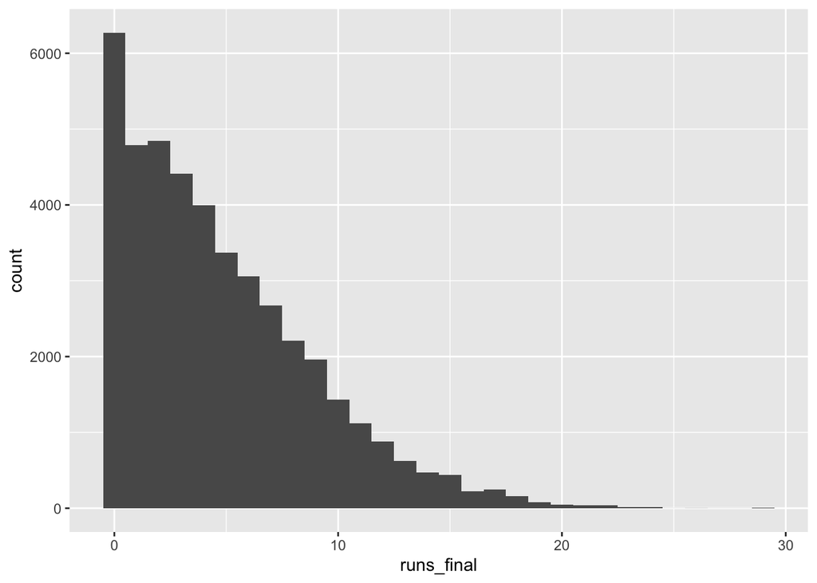

```r
# Sanity-check: how many outs do half-innings end with (most should be 3),
# and how are runs per half-inning distributed?

ggplot(half_innings, aes(x = runs_final)) + geom_histogram()
```

Join the half-inning totals back onto every play. The `inner_join` also drops any plays whose half-inning did not make it into `half_innings`. (We compute the runs for the rest of the half-inning a few steps later, once we have narrowed to complete innings.)

```r
# Join the half-inning totals (max_outs, runs_final) back onto every play.
# The inner join matches on half_inning_id, so the row count is unchanged.

dim(pbp)
```

```
[1] 193695     35
```

```r
pbp <- pbp |> inner_join(half_innings, by = "half_inning_id")

dim(pbp)
```

```
[1] 193695     37
```

```r
pbp
```

| gid | inning | top_bot | batter | pitcher | score_v | score_h | pa | single | double | triple | hr | hbp | walk | k | sb2 | cs2 | bip | roe | fc | sf | sh | outs_pre | outs_post | br1_pre | br2_pre | br3_pre | br1_post | br2_post | br3_post | … |
| --- | --- | --- | --- | --- | --- | --- | --- | --- | --- | --- | --- | --- | --- | --- | --- | --- | --- | --- | --- | --- | --- | --- | --- | --- | --- | --- | --- | --- | --- | --- |
| KCA201604030 | 1 | 0 | granc001 | volqe001 | 0 | 0 | 1 | 0 | 0 | 0 | 0 | 0 | 0 | 0 | 0 | 0 | 1 | 0 | 0 | 0 | 0 | 0 | 1 | NA | NA | NA | NA | NA | NA | … |
| KCA201604030 | 1 | 0 | wrigd002 | volqe001 | 0 | 0 | 1 | 0 | 0 | 0 | 0 | 0 | 0 | 0 | 0 | 0 | 1 | 0 | 0 | 0 | 0 | 1 | 2 | NA | NA | NA | NA | NA | NA | … |
| KCA201604030 | 1 | 0 | cespy001 | volqe001 | 0 | 0 | 1 | 0 | 0 | 0 | 0 | 0 | 0 | 0 | 0 | 0 | 1 | 0 | 0 | 0 | 0 | 2 | 3 | NA | NA | NA | NA | NA | NA | … |
| KCA201604030 | 1 | 1 | escoa003 | harvm001 | 0 | 0 | 1 | 0 | 0 | 0 | 0 | 0 | 0 | 0 | 0 | 0 | 1 | 0 | 0 | 0 | 0 | 0 | 1 | NA | NA | NA | NA | NA | NA | … |
| KCA201604030 | 1 | 1 | mousm001 | harvm001 | 0 | 0 | 1 | 0 | 0 | 0 | 0 | 0 | 0 | 0 | 0 | 0 | 1 | 1 | 0 | 0 | 0 | 1 | 1 | NA | NA | NA | mousm001 | NA | NA | … |
| KCA201604030 | 1 | 1 | cainl001 | harvm001 | 0 | 0 | 0 | 0 | 0 | 0 | 0 | 0 | 0 | 0 | 0 | 0 | 0 | 0 | 0 | 0 | 0 | 1 | 1 | mousm001 | NA | NA | NA | mousm001 | NA | … |
| KCA201604030 | 1 | 1 | cainl001 | harvm001 | 0 | 0 | 1 | 0 | 0 | 0 | 0 | 0 | 1 | 0 | 0 | 0 | 0 | 0 | 0 | 0 | 0 | 1 | 1 | NA | mousm001 | NA | cainl001 | mousm001 | NA | … |
| KCA201604030 | 1 | 1 | hosme001 | harvm001 | 0 | 0 | 1 | 1 | 0 | 0 | 0 | 0 | 0 | 0 | 0 | 0 | 1 | 0 | 0 | 0 | 0 | 1 | 1 | cainl001 | mousm001 | NA | hosme001 | NA | cainl001 | … |
| KCA201604030 | 1 | 1 | morak001 | harvm001 | 0 | 1 | 1 | 0 | 0 | 0 | 0 | 0 | 0 | 0 | 0 | 0 | 1 | 0 | 0 | 0 | 0 | 1 | 3 | hosme001 | NA | cainl001 | NA | NA | NA | … |
| KCA201604030 | 2 | 0 | dudal001 | volqe001 | 0 | 1 | 1 | 0 | 0 | 0 | 0 | 0 | 0 | 1 | 0 | 0 | 0 | 0 | 0 | 0 | 0 | 0 | 1 | NA | NA | NA | NA | NA | NA | … |

[output cut: 9990 more lines]

## 5.3 Creating the Matrix

Now the other half: label the state each play *starts* in.

We want a 3-character string like `"101"` = runners on 1st and 3rd. Remember: a base is occupied when the runner column is *not* `NA`. `as.integer(TRUE)` is `1`.

Figure out the logic on a small amount of data

```r
# Work out the logic on a few columns first: turn the three runner columns
# and the out count into a single base-out state label like "1012"
# (runners on 1st & 3rd, 2 outs). A base is occupied when its runner column
# is not missing.

pbp <- pbp |>
  mutate(base_out_pre = paste(as.integer(!is.na(br1_pre)),
                              as.integer(!is.na(br2_pre)),
                              as.integer(!is.na(br3_pre)),
                              outs_pre, sep=""))
head(pbp)
```

| gid | inning | top_bot | batter | pitcher | score_v | score_h | pa | single | double | triple | hr | hbp | walk | k | sb2 | cs2 | bip | roe | fc | sf | sh | outs_pre | outs_post | br1_pre | br2_pre | br3_pre | br1_post | br2_post | br3_post | … |
| --- | --- | --- | --- | --- | --- | --- | --- | --- | --- | --- | --- | --- | --- | --- | --- | --- | --- | --- | --- | --- | --- | --- | --- | --- | --- | --- | --- | --- | --- | --- |
| KCA201604030 | 1 | 0 | granc001 | volqe001 | 0 | 0 | 1 | 0 | 0 | 0 | 0 | 0 | 0 | 0 | 0 | 0 | 1 | 0 | 0 | 0 | 0 | 0 | 1 | NA | NA | NA | NA | NA | NA | … |
| KCA201604030 | 1 | 0 | wrigd002 | volqe001 | 0 | 0 | 1 | 0 | 0 | 0 | 0 | 0 | 0 | 0 | 0 | 0 | 1 | 0 | 0 | 0 | 0 | 1 | 2 | NA | NA | NA | NA | NA | NA | … |
| KCA201604030 | 1 | 0 | cespy001 | volqe001 | 0 | 0 | 1 | 0 | 0 | 0 | 0 | 0 | 0 | 0 | 0 | 0 | 1 | 0 | 0 | 0 | 0 | 2 | 3 | NA | NA | NA | NA | NA | NA | … |
| KCA201604030 | 1 | 1 | escoa003 | harvm001 | 0 | 0 | 1 | 0 | 0 | 0 | 0 | 0 | 0 | 0 | 0 | 0 | 1 | 0 | 0 | 0 | 0 | 0 | 1 | NA | NA | NA | NA | NA | NA | … |
| KCA201604030 | 1 | 1 | mousm001 | harvm001 | 0 | 0 | 1 | 0 | 0 | 0 | 0 | 0 | 0 | 0 | 0 | 0 | 1 | 1 | 0 | 0 | 0 | 1 | 1 | NA | NA | NA | mousm001 | NA | NA | … |
| KCA201604030 | 1 | 1 | cainl001 | harvm001 | 0 | 0 | 0 | 0 | 0 | 0 | 0 | 0 | 0 | 0 | 0 | 0 | 0 | 0 | 0 | 0 | 0 | 1 | 1 | mousm001 | NA | NA | NA | mousm001 | NA | … |

How many distinct states are there? We expect the 24 real ones — a “3 outs” state never *starts* a play, so it should not appear:

```r
# Count the distinct states to confirm we get the 24 we expect.
pbp |> group_by(base_out_pre) |> summarise(count = n())
```

| base_out_pre | count |
| --- | --- |
| 0000 | 46095 |
| 0001 | 33375 |
| 0002 | 26796 |
| 0010 | 522 |
| 0011 | 1881 |
| 0012 | 2880 |
| 0100 | 3472 |
| 0101 | 5498 |
| 0102 | 7111 |
| 0110 | 687 |

[output cut: 14 more lines]

### The state the play ends in

Same construction from the `*_post` columns, plus `outs_post`:

```r
# Build the base-out state AFTER the play, using the post-play columns.
head(pbp)
```

| gid | inning | top_bot | batter | pitcher | score_v | score_h | pa | single | double | triple | hr | hbp | walk | k | sb2 | cs2 | bip | roe | fc | sf | sh | outs_pre | outs_post | br1_pre | br2_pre | br3_pre | br1_post | br2_post | br3_post | … |
| --- | --- | --- | --- | --- | --- | --- | --- | --- | --- | --- | --- | --- | --- | --- | --- | --- | --- | --- | --- | --- | --- | --- | --- | --- | --- | --- | --- | --- | --- | --- |
| KCA201604030 | 1 | 0 | granc001 | volqe001 | 0 | 0 | 1 | 0 | 0 | 0 | 0 | 0 | 0 | 0 | 0 | 0 | 1 | 0 | 0 | 0 | 0 | 0 | 1 | NA | NA | NA | NA | NA | NA | … |
| KCA201604030 | 1 | 0 | wrigd002 | volqe001 | 0 | 0 | 1 | 0 | 0 | 0 | 0 | 0 | 0 | 0 | 0 | 0 | 1 | 0 | 0 | 0 | 0 | 1 | 2 | NA | NA | NA | NA | NA | NA | … |
| KCA201604030 | 1 | 0 | cespy001 | volqe001 | 0 | 0 | 1 | 0 | 0 | 0 | 0 | 0 | 0 | 0 | 0 | 0 | 1 | 0 | 0 | 0 | 0 | 2 | 3 | NA | NA | NA | NA | NA | NA | … |
| KCA201604030 | 1 | 1 | escoa003 | harvm001 | 0 | 0 | 1 | 0 | 0 | 0 | 0 | 0 | 0 | 0 | 0 | 0 | 1 | 0 | 0 | 0 | 0 | 0 | 1 | NA | NA | NA | NA | NA | NA | … |
| KCA201604030 | 1 | 1 | mousm001 | harvm001 | 0 | 0 | 1 | 0 | 0 | 0 | 0 | 0 | 0 | 0 | 0 | 0 | 1 | 1 | 0 | 0 | 0 | 1 | 1 | NA | NA | NA | mousm001 | NA | NA | … |
| KCA201604030 | 1 | 1 | cainl001 | harvm001 | 0 | 0 | 0 | 0 | 0 | 0 | 0 | 0 | 0 | 0 | 0 | 0 | 0 | 0 | 0 | 0 | 0 | 1 | 1 | mousm001 | NA | NA | NA | mousm001 | NA | … |

```r
pbp <- pbp |>
  mutate(base_out_post = paste(as.integer(!is.na(br1_post)),
                              as.integer(!is.na(br2_post)),
                              as.integer(!is.na(br3_post)),
                              outs_post, sep=""))

pbp |> group_by(base_out_post) |> summarise(count = n())
```

| base_out_post | count |
| --- | --- |
| 0000 | 2715 |
| 0001 | 33442 |
| 0002 | 26883 |
| 0003 | 43226 |
| 0010 | 522 |
| 0011 | 1881 |
| 0012 | 2880 |
| 0100 | 3472 |
| 0101 | 5498 |
| 0102 | 7111 |

[output cut: 15 more lines]

### Dropping plays that changed nothing

Some rows leave the base-out state untouched and score no run (a pickoff throw, a foul, a defensive substitution). They should not count as a “transition.” Keep a play only if it **changed the state** or **scored a run**:

```r
# Keep only plays that changed the base-out state or scored a run, and
# check how many rows are left.
dim(pbp)
```

```
[1] 193695     39
```

```r
pbp <- pbp |> filter(base_out_pre != base_out_post | runs > 0)
dim(pbp)
```

```
[1] 190552     39
```

### Averaging over complete innings to get the matrix

Two ingredients are (about to be) on the table:

- `base_out_pre` — where each play started (24 states)
- `runs_roi` — runs the team scored from there to the end of the inning (we compute this in the next chunk)

Run expectancy is just the **average of `runs_roi` within each `base_out_pre`**. One guardrail first: only average over **complete innings** — those that reached 3 outs (`max_outs > 2`) — because a walk-off inning ends early and understates the runs that “would have” scored.

```r
# Make a separate table of complete innings only, to estimate the matrix
# (we keep the full data for run values later).
dim(pbp)
```

```
[1] 190552     39
```

```r
complete_pbp <- pbp |> filter(max_outs > 2)
dim(complete_pbp)
```

```
[1] 189730     39
```

```r
# Compute the runs for rest of half-inning (ROI) for every plate appearance
complete_pbp <- complete_pbp |> mutate(runs_roi = runs_final - runs_pre)
```

```r
# The run expectancy matrix: the average runs-to-end-of-inning within each
# starting state. Keep a count of plays per state too.
RE24 <- complete_pbp |>
  group_by(base_out_pre) |>
  summarize(expected_runs = mean(runs_roi)) |>
  arrange(expected_runs)
RE24
```

| base_out_pre | expected_runs |
| --- | --- |
| 0002 | 0.1062081 |
| 1002 | 0.2202057 |
| 0001 | 0.2679028 |
| 0102 | 0.3125359 |
| 0012 | 0.3719534 |
| 1102 | 0.4136098 |
| 1012 | 0.4782454 |
| 0000 | 0.4981685 |
| 1001 | 0.5121337 |
| 0112 | 0.5481675 |

[output cut: 14 more lines]

That is the value function — but a 24-row column is hard to read. Reshape it into the classic **bases × outs** grid:

```r
# Reshape the matrix into a readable grid: bases down the rows, outs across
# the columns.
# readable bases x outs grid
re_grid <- RE24 |>
  mutate(bases = substr(base_out_pre, 1, 3),
         outs  = substr(base_out_pre, 4, 4)) |>
  select(bases, outs, expected_runs) |>
  pivot_wider(names_from = outs, values_from = expected_runs, names_prefix = "outs_") |>
  mutate(across(where(is.numeric), round, digits = 2)) |>
  select(bases, outs_0, outs_1, outs_2) |>
  arrange(bases)
re_grid
```

| bases | outs_0 | outs_1 | outs_2 |
| --- | --- | --- | --- |
| 000 | 0.50 | 0.27 | 0.11 |
| 001 | 1.35 | 0.94 | 0.37 |
| 010 | 1.13 | 0.67 | 0.31 |
| 011 | 1.93 | 1.36 | 0.55 |
| 100 | 0.86 | 0.51 | 0.22 |
| 101 | 1.72 | 1.20 | 0.48 |
| 110 | 1.44 | 0.92 | 0.41 |
| 111 | 2.11 | 1.54 | 0.70 |

Read it together:

> **MDP callout:** you just estimated $V(s)$ for all 24 states by Monte-Carlo averaging over real trajectories — no Bellman solve, no discounting (the inning is finite and undiscounted). The “policy” is whatever the 2016 league actually did.

## 5.4 Measuring Success of a Batting Play

Now use the formula from the top of the file. Attach $RE(\text{before})$ and $RE(\text{after})$ to every play, then apply $\;RE_{\text{after}} - RE_{\text{before}} + \text{runs}$.

### Join the RE24 matrix onto the plays — twice

First for the starting state:

```r
# Attach the run expectancy of the state BEFORE the play to every play.
complete_pbp <- complete_pbp |> left_join(RE24 |> rename(RE24_pre = expected_runs), by = "base_out_pre")
```

Then for the ending state — same table, matched on `base_out_post`:

```r
# Attach the run expectancy of the state AFTER the play, the same way.
complete_pbp <- complete_pbp |> left_join(RE24 |> rename(RE24_post = expected_runs), by = join_by(base_out_post == base_out_pre))
```

When the play ends the inning, `base_out_post` is a 3-out state that is not in the matrix, so the join gives `NA`. The value of “inning over” is 0 runs — set it:

```r
# Inning-ending plays have no "after" state in the matrix, so set that run
# expectancy to 0 (the inning is over — no more runs).
complete_pbp <- complete_pbp |> mutate(RE24_post = coalesce(RE24_post, 0))
```

### The run value

```r
# The run value of each play: the change in run expectancy plus any runs
# that scored.
complete_pbp <- complete_pbp |> mutate(run_value = RE24_post - RE24_pre + runs)
```

Sort every play by its run value to sanity-check the extremes. The most negative plays sit at the top — rally-killing outs and double plays with runners on base. Scroll to the bottom and you find the most valuable plays: grand slams, which score four *and* clear the bases:

```r
# Sort all plays by run value: the biggest rally-killers are at the top,
# the most valuable plays (e.g., grand slams) at the bottom.
complete_pbp |> arrange(run_value)
```

| gid | inning | top_bot | batter | pitcher | score_v | score_h | pa | single | double | triple | hr | hbp | walk | k | sb2 | cs2 | bip | roe | fc | sf | sh | outs_pre | outs_post | br1_pre | br2_pre | br3_pre | br1_post | br2_post | br3_post | … |
| --- | --- | --- | --- | --- | --- | --- | --- | --- | --- | --- | --- | --- | --- | --- | --- | --- | --- | --- | --- | --- | --- | --- | --- | --- | --- | --- | --- | --- | --- | --- |
| CHA201604220 | 7 | 0 | morem001 | quinj001 | 0 | 5 | 1 | 0 | 0 | 0 | 0 | 0 | 0 | 0 | 0 | 0 | 1 | 0 | 0 | 0 | 0 | 0 | 3 | desmi001 | belta001 | fielp001 | NA | NA | NA | … |
| SFN201607290 | 8 | 1 | crawb001 | solis001 | 4 | 1 | 1 | 0 | 0 | 0 | 0 | 0 | 0 | 0 | 0 | 0 | 1 | 0 | 0 | 0 | 0 | 0 | 3 | poseb001 | pagaa001 | spand001 | NA | NA | NA | … |
| MIA201605210 | 9 | 0 | wertj001 | ramoa001 | 2 | 3 | 1 | 0 | 0 | 0 | 0 | 0 | 0 | 0 | 0 | 0 | 1 | 0 | 0 | 0 | 0 | 0 | 2 | renda001 | taylm002 | murpd006 | wertj001 | renda001 | NA | … |
| CHA201605231 | 7 | 1 | sancc001 | oterd001 | 3 | 6 | 1 | 0 | 0 | 0 | 0 | 0 | 0 | 0 | 0 | 0 | 1 | 0 | 0 | 0 | 0 | 0 | 2 | lawrb002 | abrej003 | cabrm002 | lawrb002 | abrej003 | NA | … |
| ATL201605240 | 2 | 1 | aybae001 | nelsj004 | 0 | 0 | 1 | 0 | 0 | 0 | 0 | 0 | 0 | 0 | 0 | 0 | 1 | 0 | 0 | 0 | 0 | 0 | 2 | johnk003 | flowt001 | markn001 | johnk003 | flowt001 | NA | … |
| TOR201607090 | 2 | 0 | moyas001 | sanca006 | 0 | 0 | 1 | 0 | 0 | 0 | 0 | 0 | 0 | 0 | 0 | 0 | 1 | 0 | 0 | 0 | 0 | 0 | 2 | uptoj001 | castn001 | martv001 | uptoj001 | castn001 | NA | … |
| TBA201606180 | 5 | 0 | beltb001 | moorm003 | 2 | 3 | 1 | 0 | 0 | 0 | 0 | 0 | 0 | 0 | 0 | 0 | 1 | 0 | 0 | 0 | 0 | 0 | 2 | panij002 | spand001 | blang001 | panij002 | NA | blang001 | … |
| NYN201609180 | 1 | 1 | darnt001 | gibsk002 | 0 | 2 | 1 | 0 | 0 | 0 | 0 | 0 | 0 | 0 | 0 | 0 | 1 | 0 | 0 | 0 | 0 | 0 | 2 | johnk003 | confm001 | cespy001 | johnk003 | NA | cespy001 | … |
| WAS201604260 | 5 | 0 | franm004 | schem001 | 3 | 1 | 1 | 0 | 0 | 0 | 0 | 0 | 0 | 0 | 0 | 0 | 1 | 0 | 1 | 0 | 0 | 0 | 2 | NA | blana001 | herro001 | NA | blana001 | NA | … |
| TEX201604200 | 2 | 0 | gonzm002 | hamec001 | 0 | 0 | 1 | 0 | 0 | 0 | 0 | 0 | 0 | 0 | 0 | 0 | 1 | 0 | 0 | 0 | 0 | 0 | 2 | gomec002 | gatte001 | rasmc001 | NA | gomec002 | gatte001 | … |

[output cut: 9990 more lines]

## 5.5 Run values for individual hitters

Total run value is a batter’s contribution in runs. Sum each batter’s `run_value` across all of their plays (also counting `pa` to get a plate appearance total), and sort ascending so the least productive batters show up first:

```r
complete_pbp |>
  group_by(batter) |>
  summarise(num_pas = sum(pa), total_run_value = sum(run_value)) |>
  arrange(total_run_value)
```

| batter | num_pas | total_run_value |
| --- | --- | --- |
| hecha001 | 546 | -32.240197120 |
| norrd001 | 455 | -26.860707262 |
| escoa003 | 678 | -26.447016582 |
| burnb002 | 329 | -23.319713682 |
| galvf001 | 621 | -22.882826808 |
| shucj001 | 238 | -22.870842430 |
| zimmr001 | 467 | -22.861717030 |
| ahmen001 | 308 | -22.825499896 |
| martk001 | 466 | -21.693307779 |
| josec002 | 139 | -21.478557367 |

[output cut: 958 more lines]

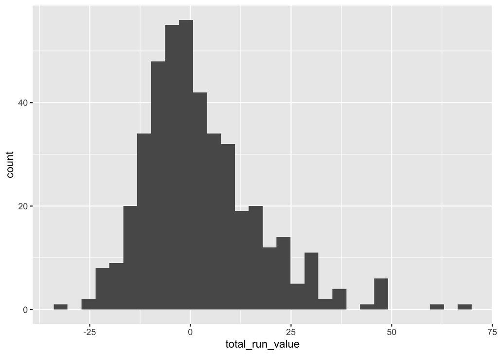

```r
# Total each batter's run value, keep batters with more than 100 PA, and
# plot the distribution of season run-value totals across those batters.
temp <- complete_pbp |>
  group_by(batter) |>
  summarise(num_pas = sum(pa), total_run_value = sum(run_value)) |>
  filter(num_pas > 100) |>
  arrange(desc(total_run_value))
ggplot(temp, aes(x = total_run_value)) + geom_histogram()
```

Check a name we know — the 2016 AL MVP, Mike Trout (`troum001`), who tops the list:

```r
# Find Mike Trout ("troum001") in the leaderboard.
complete_pbp |>
  group_by(batter) |>
  summarise(num_pas = sum(pa), total_run_value = sum(run_value)) |>
  filter(num_pas > 100) |>
  arrange(desc(total_run_value)) |>
  filter(batter == "troum001")
```

| batter | num_pas | total_run_value |
| --- | --- | --- |
| troum001 | 677 | 68.14231 |

Compare a handful of 2016 stars by hand — Trout, David Ortiz (in his farewell season), Josh Donaldson, NL MVP Kris Bryant, Mookie Betts, and José Altuve:

```r
# Pull out a handful of 2016 stars and compare their totals.
# (Trout, Ortiz, Donaldson, Bryant, Betts, Altuve.)
stars <- c("troum001", "ortid001", "donaj001", "bryak001", "bettm001", "altuj001")

complete_pbp |>
  filter(batter %in% stars) |>
  group_by(batter) |>
  summarise(num_pas = sum(pa), total_run_value = sum(run_value)) |>
  arrange(desc(total_run_value))
```

| batter | num_pas | total_run_value |
| --- | --- | --- |
| troum001 | 677 | 68.14231 |
| ortid001 | 624 | 60.25011 |
| donaj001 | 698 | 48.52771 |
| bryak001 | 696 | 47.79652 |
| bettm001 | 727 | 36.47831 |
| altuj001 | 711 | 35.00458 |

## 5.8 Run Values of Different Base Hits

The `run_value` of one home run depends on the state it happened in. Average over all the states a play type occurs in and you get its **linear weight** — the context-neutral price of that event. This is where run expectancy turns into the coefficients you have seen in wOBA and similar metrics.

### Label each plate appearance by its main outcome

Add a single `outcome` label to every play from the 0/1 event flags. The hits, walk, HBP, strikeout, sac fly (`sf`), and sac bunt (`sh`) each have their own column, but there is no column for “made an out on a ball in play.” We derive that `bip_out` category from `bip`, `roe`, and `fc` — see the comment in the chunk. Order matters: the sacrifices are pulled out first, so `bip_out` ends up meaning a *routine* batted-ball out, and the leftover `other` bucket holds the oddballs (reached-on-error, fielder’s choice), which behave very differently.

```r
complete_pbp
```

| gid | inning | top_bot | batter | pitcher | score_v | score_h | pa | single | double | triple | hr | hbp | walk | k | sb2 | cs2 | bip | roe | fc | sf | sh | outs_pre | outs_post | br1_pre | br2_pre | br3_pre | br1_post | br2_post | br3_post | … |
| --- | --- | --- | --- | --- | --- | --- | --- | --- | --- | --- | --- | --- | --- | --- | --- | --- | --- | --- | --- | --- | --- | --- | --- | --- | --- | --- | --- | --- | --- | --- |
| KCA201604030 | 1 | 0 | granc001 | volqe001 | 0 | 0 | 1 | 0 | 0 | 0 | 0 | 0 | 0 | 0 | 0 | 0 | 1 | 0 | 0 | 0 | 0 | 0 | 1 | NA | NA | NA | NA | NA | NA | … |
| KCA201604030 | 1 | 0 | wrigd002 | volqe001 | 0 | 0 | 1 | 0 | 0 | 0 | 0 | 0 | 0 | 0 | 0 | 0 | 1 | 0 | 0 | 0 | 0 | 1 | 2 | NA | NA | NA | NA | NA | NA | … |
| KCA201604030 | 1 | 0 | cespy001 | volqe001 | 0 | 0 | 1 | 0 | 0 | 0 | 0 | 0 | 0 | 0 | 0 | 0 | 1 | 0 | 0 | 0 | 0 | 2 | 3 | NA | NA | NA | NA | NA | NA | … |
| KCA201604030 | 1 | 1 | escoa003 | harvm001 | 0 | 0 | 1 | 0 | 0 | 0 | 0 | 0 | 0 | 0 | 0 | 0 | 1 | 0 | 0 | 0 | 0 | 0 | 1 | NA | NA | NA | NA | NA | NA | … |
| KCA201604030 | 1 | 1 | mousm001 | harvm001 | 0 | 0 | 1 | 0 | 0 | 0 | 0 | 0 | 0 | 0 | 0 | 0 | 1 | 1 | 0 | 0 | 0 | 1 | 1 | NA | NA | NA | mousm001 | NA | NA | … |
| KCA201604030 | 1 | 1 | cainl001 | harvm001 | 0 | 0 | 0 | 0 | 0 | 0 | 0 | 0 | 0 | 0 | 0 | 0 | 0 | 0 | 0 | 0 | 0 | 1 | 1 | mousm001 | NA | NA | NA | mousm001 | NA | … |
| KCA201604030 | 1 | 1 | cainl001 | harvm001 | 0 | 0 | 1 | 0 | 0 | 0 | 0 | 0 | 1 | 0 | 0 | 0 | 0 | 0 | 0 | 0 | 0 | 1 | 1 | NA | mousm001 | NA | cainl001 | mousm001 | NA | … |
| KCA201604030 | 1 | 1 | hosme001 | harvm001 | 0 | 0 | 1 | 1 | 0 | 0 | 0 | 0 | 0 | 0 | 0 | 0 | 1 | 0 | 0 | 0 | 0 | 1 | 1 | cainl001 | mousm001 | NA | hosme001 | NA | cainl001 | … |
| KCA201604030 | 1 | 1 | morak001 | harvm001 | 0 | 1 | 1 | 0 | 0 | 0 | 0 | 0 | 0 | 0 | 0 | 0 | 1 | 0 | 0 | 0 | 0 | 1 | 3 | hosme001 | NA | cainl001 | NA | NA | NA | … |
| KCA201604030 | 2 | 0 | dudal001 | volqe001 | 0 | 1 | 1 | 0 | 0 | 0 | 0 | 0 | 0 | 1 | 0 | 0 | 0 | 0 | 0 | 0 | 0 | 0 | 1 | NA | NA | NA | NA | NA | NA | … |

[output cut: 9990 more lines]

```r
# Label each plate appearance with its main outcome (home run, triple,
# double, single, walk, HBP, strikeout, sac fly, sac bunt, ball-in-play out,
# or other).
#
# Sac flies (sf) and sac bunts (sh) are pulled out ABOVE the bip_out branch,
# because both put the ball in play with no error and no fielder's choice, so
# they would otherwise be swept into bip_out. They behave differently from a
# routine out and are worth separating.
#
# There is no single "bip_out" column, so we build it from three flags that
# ARE in the data: bip (the batter put the ball in play), roe (reached on
# error), and fc (fielder's choice). By the time case_when reaches that
# branch, hits and sacrifices have already been peeled off above, so a ball
# in play on which the batter neither reached on an error nor was safe on a
# fielder's choice is a routine out on a batted ball (grounder, flyout,
# lineout, popup). Whatever is left over ("other") is mostly reached-on-error
# and fielder's choice -- plays where the batter was NOT put out on the ball.
complete_pbp <- complete_pbp %>%
  mutate(
    is_hit = if_else(single == 1 | double == 1 | triple == 1 | hr == 1, 1, 0),
    outcome = case_when(
      single == 1 ~ "single",
      double == 1 ~ "double",
      triple == 1 ~ "triple",
      hr     == 1 ~ "hr",
      hbp    == 1 ~ "hbp",
      walk   == 1 ~ "walk",
      k      == 1 ~ "k",
      sf     == 1 ~ "sac_fly",
      sh     == 1 ~ "sac_bunt",
      bip == 1 & roe == 0 & fc == 0 ~ "bip_out",
      TRUE        ~ "other"
    )
  )
```

```r
complete_pbp |>
  filter(pa == 1) |>
  group_by(outcome) |>
  summarise(mean_run_value = mean(run_value)) |>
  arrange(desc(mean_run_value))
```

| outcome | mean_run_value |
| --- | --- |
| hr | 1.3808929 |
| triple | 1.0141703 |
| double | 0.7385658 |
| single | 0.4377376 |
| hbp | 0.3166272 |
| other | 0.3031946 |
| walk | 0.2842011 |
| sac_fly | -0.0100122 |
| sac_bunt | -0.1375378 |
| k | -0.2644293 |

[output cut: 1 more lines]

**NoteEnd of in-class live coding**

Everything above this line is what we built together in class, through the per-event run values just above in §5.8. (Two short lookups in §5.5 — finding Mike Trout on the leaderboard and comparing a handful of 2016 stars — were left blank during class and have been filled in above.)

Everything **below** this line was completed after class: the linear-weight ladder, how a single’s value depends on the base-out state, the value of base stealing, and the actual-vs-expected comparison for all hitters.

### Average run value per event = linear weights

```r
# Linear weights: the average run value of each event type, ranked. Save the
# table so we can reuse each event's weight (its context-neutral price) later.
linear_weights <- complete_pbp |>
  filter(pa == 1) |>
  group_by(outcome) |>
  summarise(mean_run_value = mean(run_value)) |>
  arrange(desc(mean_run_value))
linear_weights
```

| outcome | mean_run_value |
| --- | --- |
| hr | 1.3808929 |
| triple | 1.0141703 |
| double | 0.7385658 |
| single | 0.4377376 |
| hbp | 0.3166272 |
| other | 0.3031946 |
| walk | 0.2842011 |
| sac_fly | -0.0100122 |
| sac_bunt | -0.1375378 |
| k | -0.2644293 |

[output cut: 1 more lines]

Talk through the ladder: home run on top (well over a run), then triple, double, single, then walk and HBP. The two full outs — `bip_out` and `k` — sit at the bottom, both worth about **−0.26 runs**: to run expectancy, a strikeout and a routine grounder cost almost exactly the same. That negative number is exactly why “productive out” is mostly a myth, and it is the same shape as the coefficients hitters get paid on.

The two sacrifices land in between, and this is where breaking them out pays off. A **sac fly is worth about −0.01 — essentially free**: the run it drives in almost exactly cancels the out it costs, which is the whole point of the play. A **sac bunt is about −0.14**: still negative (you are handing the defense an out), but only *half* a routine out, because the runners you advance buy back some of the lost run expectancy. That gap is the crux of the “is the bunt worth it?” debate.

Notice that `other` is now *positive*. Peeling the batted-ball outs and sacrifices away left `other` holding mostly reached-on-error and fielder’s-choice plays — where the batter typically ends up **on base**, so the average run value is positive. That is the payoff of separating these categories out: the outs no longer contaminate the leftover bucket.

### How the value of a single depends on the state

Linear weights *averaged away* the state. But the run value of a single clearly depends on whether anyone is on base. Show it:

```r
# Look at just the singles and find the average run value by base-out
# state, to show a single is worth more in some situations than others.
complete_pbp |>
  filter(single == 1) |>
  group_by(base_out_pre) |>
  summarise(mean_run_value = mean(run_value), n = n()) |>
  arrange(desc(mean_run_value))
```

| base_out_pre | mean_run_value | n |
| --- | --- | --- |
| 1112 | 1.5727940 | 250 |
| 0112 | 1.4754292 | 203 |
| 1111 | 1.2103003 | 266 |
| 1110 | 1.1825404 | 109 |
| 1012 | 0.9503292 | 360 |
| 0111 | 0.9368769 | 222 |
| 1101 | 0.8728765 | 683 |
| 0012 | 0.8472303 | 352 |
| 1102 | 0.8415219 | 721 |
| 0110 | 0.8284177 | 87 |

[output cut: 14 more lines]

A single with runners in scoring position is worth far more than a single with the bases empty. Linear weights are the *average* over how often each situation comes up — useful for a season line, but not the value of any specific play.

## 5.9 Value of Base Stealing

Every play already has a `run_value`, including steals and caught-stealings. Average the run value of a successful steal of second and of a caught stealing at second:

```r
# Find the average run value of a steal of 2nd and of a caught stealing
# at 2nd. (sb2 flags a stolen base of 2nd; cs2 flags a caught stealing at 2nd.)
steal_values <- complete_pbp |>
  summarise(rv_sb2 = mean(run_value[sb2 == 1]),
            rv_cs2 = mean(run_value[cs2 == 1]),
            n_sb2  = sum(sb2 == 1),
            n_cs2  = sum(cs2 == 1))
steal_values
```

| rv_sb2 | rv_cs2 | n_sb2 | n_cs2 |
| --- | --- | --- | --- |
| 0.1410857 | -0.4206081 | 2135 | 872 |

A steal gains a little; a caught stealing costs a lot (you lose the runner *and* buy an out). The break-even success rate $p$ solves $p \cdot RV_{SB} + (1-p) \cdot RV_{CS} = 0$:

```r
# Use those two values to solve for the break-even success rate:
# p * RV_SB + (1 - p) * RV_CS = 0  ->  p = -RV_CS / (RV_SB - RV_CS).
break_even <- with(steal_values, -rv_cs2 / (rv_sb2 - rv_cs2))
break_even
```

```
[1] 0.748821
```

Right around 75%. Steal only if you beat that rate — a genuinely actionable number that falls straight out of the run expectancy matrix.

## Actual vs. linear-weight run value (all hitters)

*This is the book’s §5.6 comparison (“Opportunity and Success for All Hitters”), run for every 2016 hitter.*

We have two ways to price a hitter’s season, both in runs:

- **Actual run value** — sum each plate appearance’s `run_value`, which is built from the *actual* base-out state before and after the play. This is **context-dependent**: it credits the hitter for **when** things happened (a single with the bases loaded is worth more than a single with the bases empty).
- **Linear-weight run value** — replace each plate appearance with the league-average value of that event type (its linear weight), then sum. This is **context-neutral**: it only cares about **what** the hitter did, not the situation.

Comparing the two shows how much of a hitter’s value is explained by their events (linear weights) versus their situational timing (the gap between the two totals).

```r
# For each hitter, compute two season totals:
#  - actual run value (context-dependent): sum the run_value of every PA
#  - linear-weight run value (context-neutral): sum the league-average value
#    of each PA's event type
# Attach each PA's linear weight, keep regulars, and rank by actual value.
pa_data <- complete_pbp |>
  filter(pa == 1) |>
  left_join(linear_weights, by = "outcome")

hitter_values <- pa_data |>
  group_by(batter) |>
  summarise(num_pas   = n(),
            actual_rv = sum(run_value),
            lw_rv     = sum(mean_run_value)) |>
  mutate(diff = actual_rv - lw_rv) |>
  filter(num_pas > 400) |>
  arrange(desc(actual_rv))
hitter_values
```

| batter | num_pas | actual_rv | lw_rv | diff |
| --- | --- | --- | --- | --- |
| troum001 | 677 | 65.20851903 | 56.3664763 | 8.84204272 |
| ortid001 | 624 | 58.53346722 | 50.1527722 | 8.38069498 |
| freef001 | 692 | 46.18363825 | 46.5576081 | -0.37396986 |
| donaj001 | 698 | 46.10047097 | 47.3781133 | -1.27764234 |
| vottj001 | 673 | 45.75184571 | 49.7865713 | -4.03472555 |
| bryak001 | 696 | 45.68841038 | 44.2234539 | 1.46495644 |
| arenn001 | 694 | 45.33340948 | 37.8037053 | 7.52970417 |
| murpd006 | 581 | 44.57947680 | 41.5198581 | 3.05961873 |
| rizza001 | 672 | 40.19049743 | 36.2307181 | 3.95977933 |
| bettm001 | 727 | 35.65333008 | 35.4364482 | 0.21688192 |

[output cut: 193 more lines]

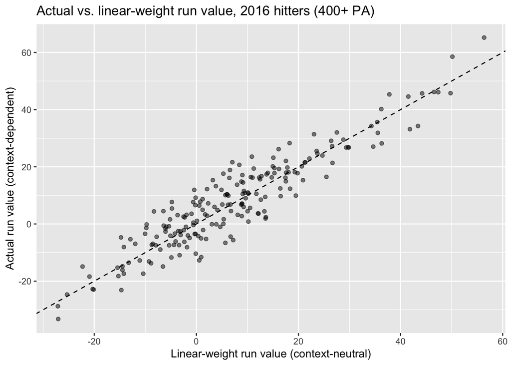

```r
# Scatter actual against linear-weight run value for all hitters, with a
# 45-degree reference line. Points on the line mean linear weights fully
# explain the hitter; distance from the line is situational timing.
ggplot(hitter_values, aes(x = lw_rv, y = actual_rv)) +
  geom_point(alpha = 0.5) +
  geom_abline(slope = 1, intercept = 0, linetype = "dashed") +
  labs(x = "Linear-weight run value (context-neutral)",
       y = "Actual run value (context-dependent)",
       title = "Actual vs. linear-weight run value, 2016 hitters (400+ PA)")
```

```r
# Correlation between the two measures.
cor(hitter_values$actual_rv, hitter_values$lw_rv)
```

```
[1] 0.9287092
```

Points sit close to the 45° line: linear weights recover most of a hitter’s run contribution (the correlation is about 0.93 across qualified hitters). The vertical gap from the line is the situational piece — extra runs from hitting in higher-leverage spots — which is mostly sequencing luck and does not repeat well year to year.